# Kinematic Equations

Eugene

Wednesday, 10 March, 2021

## Theory

This week we’re going to do a lab based on the kinematic equations. We’re going to fire projectiles straight up and measure how far they rise, and what time they take to get to the top. We’re then going to plot two separate relationships, each one will give us a value for the acceleration due to gravity. We can then compare that to the text book value.

## Set-Up and Results

Go to the projectile motion experiment on the [PHET website](https://phet.colorado.edu/sims/html/projectile-motion/latest/projectile-motion_en.html). Go to the *Lab* tag here.

1. Orient the cannon to be vertical (set the angle to $90^{\circ}$), set the **initial velocity** to be 10 m/s. and fire the cannon.

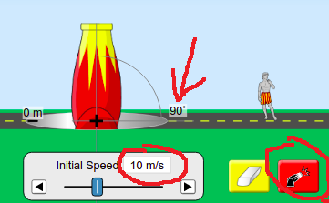

2. Drag the measurement box down from the utilities section in the top right corner, and place the cross-hairs exactly over the very top part of the cannonball’s flight. Record the **Time** and **Height**.

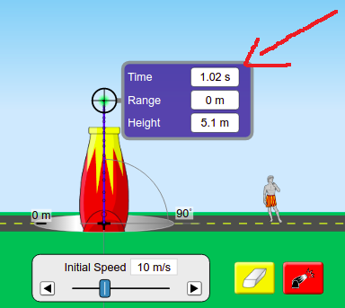

3. Erase the cannonball track with the yellow eraser. Reset the **Initial Speed** to 12 m/s and fire the cannon ball again. Again, record the **Time** and **Height**. Keep doing this. For higher speeds, you’ll need to adjust the scale magnifiers (as shown below for 20 m/s).

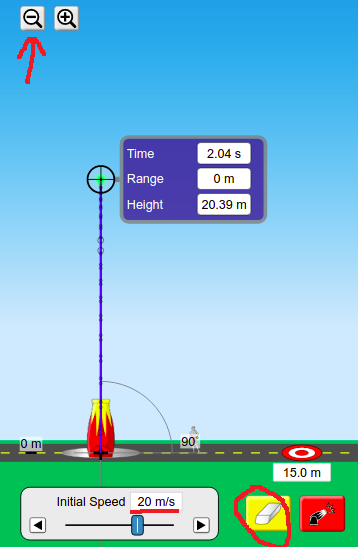

4. Fill out the table below.

## Table

Fill out a table as shown below. A handful of my measurements have been included just to give you an idea of the kind of figures to expect, you should replace these values with your own which are more accurate.

| **v<sub>0</sub>(m/s)** | **v<sub>0</sub><sup>2</sup>(m<sup>2</sup>/s<sup>2</sup>)** | **t(s)** | **h(m)** |
| --- | --- | --- | --- |
| 10 | 100 | 1.02 | 5.1 |
| 12 | 144 |  |  |
| 14 | 196 |  |  |
| 16 | 256 | 1.63 |  |
| 18 | 324 |  |  |
| 20 | 400 |  |  |
| 22 | 484 |  | 24.67 |
| 24 | 576 |  |  |
| 26 | 676 |  |  |
| 28 | 784 |  |  |
| 30 | 900 |  |  |

## Graph

Plot a graph of initial velocity ($v_0$) versus time. Calculate the slope of this line. It should look a little like the graph sketched below.

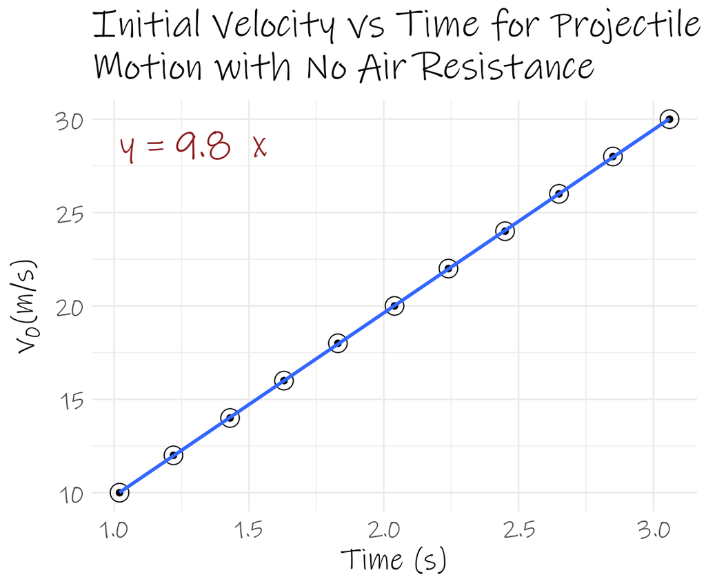

Plot a graph of initial velocity squared ($v_0^2$) versus height. Calculate the slope of this line. It should look a little like the graph sketched below.

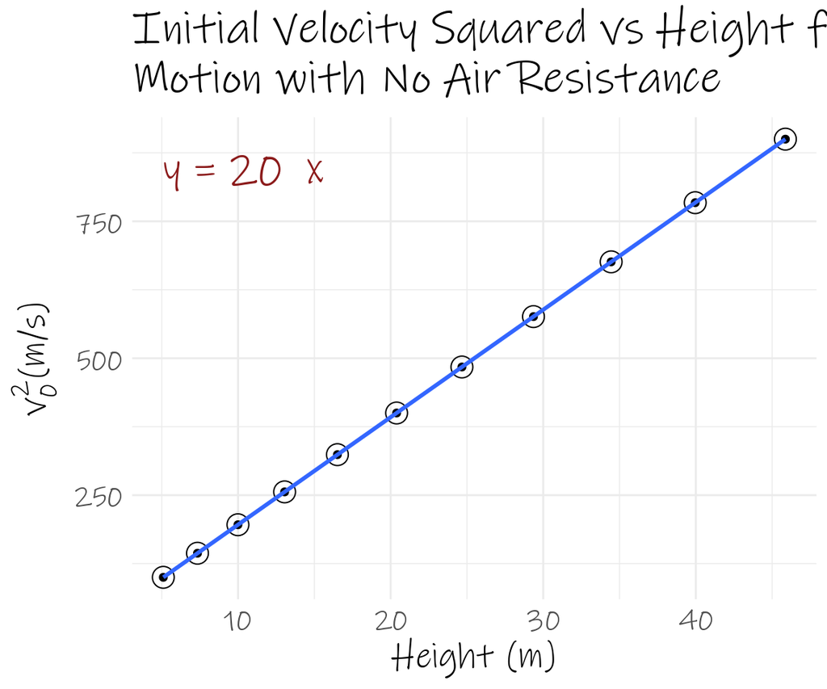

## Analysis

The slope of the first graph will be equal to $g$ (using $v\:=\:v_0\:+\:at$ and taking into account the opposite directions of $v_0$ and g).  
So the slope of the first graph will be a measurement of *g*.

The slope of the second graph will be equal to $2\times g$ (using $v^2\:=\:v_0^2\:+\:2 \times a \times s$ and again taking into account the opposite directions of $v_0$ and g).  
So the *g* will be equal to the slope of the second graph divided by *2*.

## Discussion

The reference value for $g$ is $9.81 m/s^2$.